# main

# Data Preparation and preprocessing

```r
data = readRDS(here::here("Main RCT analyses/raw_data.rds"))
# We only keep the variables that are necessary for the primary analysis
data_primary <- data |>
  select(
    WINS.ID,
    Treatment,
    HEI2015_TOTAL_SCORE_bl,
    HEI2015_TOTAL_SCORE_el,
    HEI2015_TOTAL_SCORE_change,
    Age_years,
    Sex_bcf,
    Race2_bcf,
    Ethnicity_bcf,
    Education_grouped
  ) |>
  mutate(Completion = ifelse(is.na(HEI2015_TOTAL_SCORE_el), 0, 1), .after = Treatment)

head(data_primary)
```

```
   WINS.ID Treatment Completion HEI2015_TOTAL_SCORE_bl HEI2015_TOTAL_SCORE_el
1 WINS5002 Treatment          1               77.75465               55.12924
2 WINS5004   Control          1               37.74904               60.26091
3 WINS5005   Control          1               45.63586               43.26013
4 WINS5006   Control          1               30.21764               38.64263
5 WINS5008 Treatment          1               75.79108               78.74916
6 WINS5010   Control          1               48.68803               73.81579
  HEI2015_TOTAL_SCORE_change Age_years Sex_bcf Race2_bcf Ethnicity_bcf
1                 -22.625406        33    Male     Asian            No
2                  22.511868        50  Female     White            No
3                  -2.375731        35  Female     White            No
4                   8.424983        24    Male     White            No
5                   2.958082        51  Female     White            No
6                  25.127760        39    Male     White            No
  Education_grouped
1         >=Masters
2      <=Associates
3      <=Associates
4         >=Masters
5      <=Associates
6         >=Masters
```

The data have the following characteristics:

- It is a conditional randomized experiment. According to SAP(statistical analysis plan), it is stratified on sex.
- We do not know whether someone follows the treatment or not. We only know the treatment assignment. (This means $ITT_{Y,sex}=ATE_{sex}$)
- There are people failing to follow up at the end of the experiment. We need to handle this bias.

Notation

- $Z_i\in \left\{0,1\right\}$: treatment assignment for individual $i$.
- $Y_i$: outcome for individual $i$.
- $sex_i$: sex for individual $i$.
- $R_i\in \left\{0,1\right\}$: follow-up indicator for individual $i$. $R_i=1$ means individual $i$ has follow-up, otherwise $R_i=0$.
- $X_i$: baseline covariates for individual $i$.

If there is no missing follow-up, the ATE will be:
$$ATE_{male}=\mathbb{E}[Y_i\vert Z_i=1,sex_i=male]-\mathbb{E}[Y_i\vert Z_i=0,sex_i=male]$$
$$ATE_{female}=\mathbb{E}[Y_i\vert Z_i=1,sex_i=female]-\mathbb{E}[Y_i\vert Z_i=0,sex_i=female]$$
$$ATE=\mathbb{P}(male)ATE_{male}+\mathbb{P}(female)ATE_{female}$$
However, what if there are missing follow-up?

We still have conditional randomization:

$$Z_i\perp (Y_i(1),Y_i(0))\vert sex_i$$

Is this missing follow-up biased? We should check!

```r
# library(dplyr)
# library(broom)
#
# # baseline covariates
# baseline_vars <- c(
#   "Treatment",
#   "Sex_bcf",
#   "HEI2015_TOTAL_SCORE_bl",
#   "Age_years",
#   "Race2_bcf",
#   "Ethnicity_bcf",
#   "Education_grouped"
# )
#
# results <- lapply(baseline_vars, function(var){
#   f <- as.formula(paste("Completion ~", var))
#   fit <- glm(f, data=data_primary, family=binomial())
#   tidy(fit)[2, c("term","estimate","std.error","p.value")]
# }) %>%
#   bind_rows() %>%
#   mutate(
#     OR = exp(estimate),
#     CI_low  = exp(estimate - 1.96*std.error),
#     CI_high = exp(estimate + 1.96*std.error)
#   ) %>%
#   select(term, OR, CI_low, CI_high, p.value)
#
# results
#
# library(ggplot2)
#
# ggplot(data_primary, aes(x = HEI2015_TOTAL_SCORE_bl, fill = factor(Completion))) +
#   geom_density(alpha = 0.5) +
#   labs(fill="Completed Follow-up",
#        title="Baseline HEI score vs. Follow-up completion") +
#   theme_minimal()
library(dplyr)
library(tidyr)
library(kableExtra)
# 改进的函数：添加变量名称列
make_missing_table <- function(data, var){
  data %>%
    mutate(Completion = factor(Completion, labels = c("Missed","Completed"))) %>%
    group_by(!!sym(var), Completion) %>%
    summarise(n = n(), .groups="drop") %>%
    group_by(!!sym(var)) %>%
    mutate(pct = round(n / sum(n) * 100, 1)) %>%
    pivot_wider(
      names_from = Completion,
      values_from = c(n, pct),
      names_glue = "{Completion}_{.value}"
    ) %>%
    mutate(
      # `More likely to miss?` = ifelse(`Missed_pct` > `Completed_pct`, "⬆ Yes", "No"),
      Variable = var  # 添加变量名
    ) %>%
    arrange(desc(`Missed_pct`)) %>%
    rename(Level = !!sym(var)) %>%
    select(Variable, everything())  # 将Variable列放在最前面
}

vars_to_check <- c("Sex_bcf", "Education_grouped", "Race2_bcf",
                   "Ethnicity_bcf", "Treatment")

# 合并所有表格
combined_table <- lapply(vars_to_check, function(v){
  make_missing_table(data_primary, v)
}) %>%
  bind_rows()

# 生成一张综合表格
combined_table %>%
  kbl(
    caption = "Missingness Pattern Analysis by Demographic Variables",
    align = "llcccccc",
    booktabs = TRUE
  ) %>%
  kable_styling(
    full_width = FALSE,
    latex_options = c("striped", "hold_position")
  ) %>%
  column_spec(1, bold = TRUE) %>%
  collapse_rows(columns = 1, valign = "top")  # 合并相同变量的行
```

Missingness Pattern Analysis by Demographic Variables

| Variable | Level | Missed_n | Completed_n | Missed_pct | Completed_pct |
| --- | --- | --- | --- | --- | --- |
| Sex_bcf | Female | 30 | 268 | 10.1 | 89.9 |
|  | Male | 5 | 73 | 6.4 | 93.6 |
| Education_grouped | Bach/Some Grad | 15 | 118 | 11.3 | 88.7 |
|  | <=Associates | 12 | 104 | 10.3 | 89.7 |
|  | >=Masters | 8 | 119 | 6.3 | 93.7 |
| Race2_bcf | Asian | 6 | 22 | 21.4 | 78.6 |
|  | White | 23 | 249 | 8.5 | 91.5 |
|  | Native Hawaiian or other Pacific Islander, Multiracial, Other or Prefer not to say | 2 | 22 | 8.3 | 91.7 |
|  | Black or African-American | 4 | 48 | 7.7 | 92.3 |
| Ethnicity_bcf | No | 34 | 306 | 10.0 | 90.0 |
|  | Yes | 1 | 35 | 2.8 | 97.2 |
| Treatment | Treatment | 27 | 160 | 14.4 | 85.6 |
|  | Control | 8 | 181 | 4.2 | 95.8 |

Maybe the missingness depends on baseline variables, therefore we use IPW.

We assume MAR(missing at random):
$$R_i\perp Y_i(z)\vert (Z_i, X_i)$$

Then we can use IPW for follow-up.

Steps:

1. Model the probability of being followed:
   $$\pi_i=\mathbb{P}(R_i\vert Z_i, sex_i, X_i)$$
   using logistic regression
2. Define weights for complete cases:
   $$w_i=\frac{1}{\hat{\pi}_i}$$
   for $R_i=1$
3. Within each sex stratum $sex$, estimate the outcome means using Horvitz-Thompson type estimator:(we cannot directly use the formula in class because it is designed for estimation without missingness, although it is also Horvitz-Thompson type estimator)
   $$\hat{\mu}_{HT}=\frac{1}{N}\sum_{i=1}^n\frac{Y_i}{\pi_i}$$

Using this type of estimator, we can set up the estimator for ATE for a given sex as:

$$\hat{\mu}^{IPW}_{z,sex}=\frac{1}{N_{sex}}\sum_{\left\{i:sex_i=sex\right\} }\frac{R_i\boldsymbol{1}\left\{Z_i=z\right\}Y_i}{\hat{\pi}_i\mathbb{P}(Z=z\vert sex)}$$
Proof that this is unbiased:

By LLN, we have
$$\hat{\mu}_{z,sex}^{IPW}=\frac{1}{N_{sex}}\sum_{\left\{ i:sex_i=sex \right\}}{\frac{R_i1\left\{ Z_i=z \right\} Y_i}{\hat{\pi}_i\mathbb{P} (Z=z\vert sex)}}\rightarrow \mathbb{E} \left[ \frac{R_i1\left\{ Z_i=z \right\} Y_i}{\hat{\pi}_i\mathbb{P} (Z=z\vert sex)} \right]$$

$$\mathbb{E} \left[ \frac{R_i1\left\{ Z_i=z \right\} Y_i}{\hat{\pi}_i\mathbb{P} (Z=z\vert sex)} \right] =\mathbb{E} _{Z,X,Y}\left[ \mathbb{E} \left[ \frac{R_i1\left\{ Z_i=z \right\} Y_i}{\hat{\pi}_i\mathbb{P} (Z=z\vert sex)}\vert Z_i,X_i,Y_i \right] \vert sex \right]$$
For the inner expectation,
$$\mathbb{E} \left[ \frac{R_i1\left\{ Z_i=z \right\} Y_i}{\hat{\pi}_i\mathbb{P} (Z=z\vert sex)} \right] =\mathbb{E} _{Z,X,Y}\left[ \mathbb{E} \left[ \frac{R_i1\left\{ Z_i=z \right\} Y_i}{\hat{\pi}_i\mathbb{P} (Z=z\vert sex)}\vert Z_i,X_i,Y_i \right] \vert sex \right]$$
$$\mathbb{E} \left[ \frac{R_i1\left\{ Z_i=z \right\} Y_i}{\hat{\pi}_i\mathbb{P} (Z=z\vert sex)}\vert Z_i,X_i,Y_i \right] =\mathbb{E} \left[ R_i\vert Z_i,X_i,Y_i \right] \frac{1\left\{ Z_i=z \right\} Y_i}{\hat{\pi}_i\mathbb{P} (Z=z\vert sex)}$$

Plugging in,

$$\mathbb{E} _{Z,X,Y}\left[ \mathbb{E} \left[ \frac{R_i1\left\{ Z_i=z \right\} Y_i}{\hat{\pi}_i\mathbb{P} (Z=z|sex)}|Z_i,X_i,Y_i \right] |sex \right] =\mathbb{E} _{Z,X,Y}\left[ \frac{1\left\{ Z_i=z \right\} Y_i}{\mathbb{P} (Z=z|sex)}|sex \right]
\\
=\mathbb{E} _{Z,X,Y}\left[ \frac{1\left\{ Z_i=z \right\} Y_i\left( z \right)}{\mathbb{P} (Z=z|sex)}|sex \right]
\\
=\frac{\mathbb{E} \left[ Y_i\left( z \right) |sex \right] \mathbb{E} \left[ 1\left\{ Z_i=z \right\} |sex \right]}{\mathbb{P} (Z=z|sex)}
\\
=\mathbb{E} \left[ Y_i\left( z \right) |sex \right]$$

```r
## 1) 拟合随访模型：π_i = P(R_i = 1 | Z_i, sex_i, X_i)
followup_model <- glm(
  Completion ~ Treatment + Sex_bcf +
    HEI2015_TOTAL_SCORE_bl + Age_years +
    Race2_bcf + Ethnicity_bcf + Education_grouped,
  data   = data_primary,
  family = binomial()
)

## 2) π_hat & 权重 w_i = 1/pi_hat（仅 R=1 生效）
data_ipw <- data_primary |>
  mutate(
    Treatment_num = as.numeric(Treatment) - 1,
    pi_hat = predict(followup_model, type = "response"),
    w_ipw  = ifelse(Completion == 1, 1 / pi_hat, 0)
  )


## 3) 分 sex 计算 Horvitz–Thompson ATE
estimate_by_sex <- function(df) {
  df_comp <- df[df$Completion == 1, ]

  N_treat <- sum(df$Treatment_num == 1)
  N_ctrl  <- sum(df$Treatment_num == 0)

  if (N_treat == 0 | N_ctrl == 0) {
    warning("One group missing in this sex stratum")
    return(tibble(
      N_treat = N_treat,
      N_ctrl  = N_ctrl,
      ATE_HT  = NA_real_
    ))
  }

  mu1_HT <- with(
    df_comp,
    sum(w_ipw * (Treatment_num == 1) * HEI2015_TOTAL_SCORE_el) / N_treat
  )

  mu0_HT <- with(
    df_comp,
    sum(w_ipw * (Treatment_num == 0) * HEI2015_TOTAL_SCORE_el) / N_ctrl
  )

  ATE_HT <- mu1_HT - mu0_HT

  tibble(
    N_treat = N_treat,
    N_ctrl  = N_ctrl,
    ATE_HT  = ATE_HT
  )
}

## 4) 按 sex 分层估计 ITT_{Y,sex}
ests_by_sex <- data_ipw |>
  group_by(Sex_bcf) |>
  group_modify(~ estimate_by_sex(.x)) |>
  ungroup()

ests_by_sex
```

```
# A tibble: 2 × 4
  Sex_bcf N_treat N_ctrl ATE_HT
  <chr>     <int>  <int>  <dbl>
1 Female      149    149   3.76
2 Male         38     40   4.12
```

```r
## 5) overall ATE_HT（按样本中 sex 比例加权）
p_sex <- data_ipw |>
  count(Sex_bcf) |>
  mutate(p = n / sum(n)) |>
  select(Sex_bcf, p)

ATE_HT_overall <- ests_by_sex |>
  left_join(p_sex, by = "Sex_bcf") |>
  summarise(
    ATE_HT_overall = sum(p * ATE_HT, na.rm = TRUE)
  )

ATE_HT_overall
```

```
# A tibble: 1 × 1
  ATE_HT_overall
           <dbl>
1           3.83
```

```r
## Bootstrap for IPW estimator
set.seed(2025)  # for reproducibility
B <- 1000  # number of bootstrap samples

bootstrap_ipw_ate <- function(data, indices) {
  # Resample with replacement
  boot_data <- data[indices, ]

  # 1) Fit propensity model for follow-up
  followup_model <- glm(
    Completion ~ Treatment + Sex_bcf +
      HEI2015_TOTAL_SCORE_bl + Age_years +
      Race2_bcf + Ethnicity_bcf + Education_grouped,
    data   = boot_data,
    family = binomial()
  )

  # 2) Calculate weights
  boot_data <- boot_data |>
    mutate(
      Treatment_num = as.numeric(Treatment) - 1,
      pi_hat = predict(followup_model, type = "response"),
      w_ipw  = ifelse(Completion == 1, 1 / pi_hat, 0)
    )

  # 3) Sex-specific ATE estimates
  estimate_by_sex_boot <- function(df) {
    df_comp <- df[df$Completion == 1, ]

    N_treat <- sum(df$Treatment_num == 1)
    N_ctrl  <- sum(df$Treatment_num == 0)

    if (N_treat == 0 | N_ctrl == 0) {
      return(tibble(ATE_HT = NA_real_))
    }

    mu1_HT <- with(
      df_comp,
      sum(w_ipw * (Treatment_num == 1) * HEI2015_TOTAL_SCORE_el) / N_treat
    )

    mu0_HT <- with(
      df_comp,
      sum(w_ipw * (Treatment_num == 0) * HEI2015_TOTAL_SCORE_el) / N_ctrl
    )

    tibble(ATE_HT = mu1_HT - mu0_HT)
  }

  ests_by_sex <- boot_data |>
    group_by(Sex_bcf) |>
    group_modify(~ estimate_by_sex_boot(.x)) |>
    ungroup()

  # 4) Overall ATE (weighted by sex proportions in bootstrap sample)
  p_sex <- boot_data |>
    count(Sex_bcf) |>
    mutate(p = n / sum(n))

  ATE_overall <- ests_by_sex |>
    left_join(p_sex, by = "Sex_bcf", relationship = "many-to-many") |>
    summarise(ATE = sum(p * ATE_HT, na.rm = TRUE)) |>
    pull(ATE)

  # Return: overall ATE + sex-specific ATEs
  c(
    ATE_overall = ATE_overall,
    ATE_Female = ests_by_sex$ATE_HT[ests_by_sex$Sex_bcf == "Female"],
    ATE_Male = ests_by_sex$ATE_HT[ests_by_sex$Sex_bcf == "Male"]
  )
}

# Run bootstrap
library(boot)
boot_results <- boot(
  data = data_primary,
  statistic = bootstrap_ipw_ate,
  R = B
)
```

[output not shown]

```r
# Extract results
boot_results
```

```
ORDINARY NONPARAMETRIC BOOTSTRAP


Call:
boot(data = data_primary, statistic = bootstrap_ipw_ate, R = B)


Bootstrap Statistics :
    original       bias    std. error
t1* 3.834561  0.003002614    1.505486
t2* 3.761145  0.022990597    1.984808
t3* 4.115046 -0.088986322    4.357251
```

```r
# Confidence intervals (percentile method)
ci_overall <- boot.ci(boot_results, type = "perc", index = 1)
ci_female  <- boot.ci(boot_results, type = "perc", index = 2)
ci_male    <- boot.ci(boot_results, type = "perc", index = 3)

# Display results nicely
results_summary <- tibble(
  Estimand = c("Overall ATE", "ATE (Female)", "ATE (Male)"),
  Estimate = c(
    ATE_HT_overall$ATE_HT_overall,
    ests_by_sex$ATE_HT[ests_by_sex$Sex_bcf == "Female"],
    ests_by_sex$ATE_HT[ests_by_sex$Sex_bcf == "Male"]
  ),
  SE = c(
    sd(boot_results$t[, 1]),
    sd(boot_results$t[, 2]),
    sd(boot_results$t[, 3])
  ),
  CI_lower = c(
    ci_overall$percent[4],
    ci_female$percent[4],
    ci_male$percent[4]
  ),
  CI_upper = c(
    ci_overall$percent[5],
    ci_female$percent[5],
    ci_male$percent[5]
  )
)

print(results_summary, digits = 3)
```

```
# A tibble: 3 × 5
  Estimand     Estimate    SE CI_lower CI_upper
  <chr>           <dbl> <dbl>    <dbl>    <dbl>
1 Overall ATE      3.83  1.51    0.939     6.98
2 ATE (Female)     3.76  1.98   -0.214     7.49
3 ATE (Male)       4.12  4.36   -3.88     13.0
```

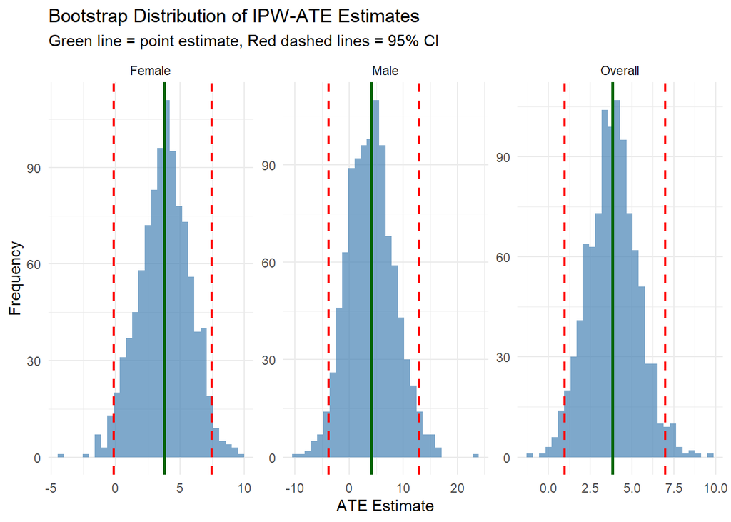

```r
# Plot bootstrap distributions
library(ggplot2)
library(tidyr)

boot_dist <- tibble(
  Overall = boot_results$t[, 1],
  Female = boot_results$t[, 2],
  Male = boot_results$t[, 3]
) |>
  pivot_longer(everything(), names_to = "Stratum", values_to = "ATE")

# Calculate 95% CI for each stratum
ci_data <- boot_dist |>
  group_by(Stratum) |>
  summarise(
    lower = quantile(ATE, 0.025, na.rm = TRUE),
    upper = quantile(ATE, 0.975, na.rm = TRUE),
    .groups = "drop"
  )

# Also get point estimates
point_estimates <- tibble(
  Stratum = c("Overall", "Female", "Male"),
  Estimate = c(
    ATE_HT_overall$ATE_HT_overall,
    ests_by_sex$ATE_HT[ests_by_sex$Sex_bcf == "Female"],
    ests_by_sex$ATE_HT[ests_by_sex$Sex_bcf == "Male"]
  )
)

# Create the plot
ggplot(boot_dist, aes(x = ATE)) +
  geom_histogram(bin = 1, alpha = 0.7, fill = "steelblue") +
  # Add vertical lines for CI bounds
  geom_vline(data = ci_data, aes(xintercept = lower),
             color = "red", linetype = "dashed", linewidth = 0.8) +
  geom_vline(data = ci_data, aes(xintercept = upper),
             color = "red", linetype = "dashed", linewidth = 0.8) +
  # Add vertical line for point estimate
  geom_vline(data = point_estimates, aes(xintercept = Estimate),
             color = "darkgreen", linewidth = 1) +
  facet_wrap(~ Stratum, scales = "free") +
  theme_minimal() +
  labs(title = "Bootstrap Distribution of IPW-ATE Estimates",
       subtitle = "Green line = point estimate, Red dashed lines = 95% CI",
       x = "ATE Estimate",
       y = "Frequency")
```